# Assignment_2

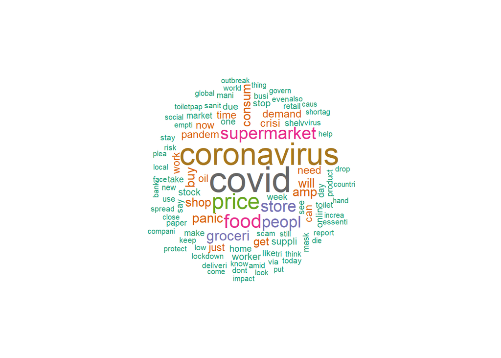

```r
wordcloud(words = names(freq_negative), freq = freq_negative, max.words = 100, random.order = FALSE, colors = brewer.pal(8, "Dark2"), scale=c(3, 0.5))
```

```r
# Create wordclouds for the top 100 most frequent words in positive and negative tweets
#wordcloud(words = names(freq_positive), freq = freq_positive, max.words = 100, random.order = FALSE, colors = brewer.pal(8, "Dark2"), scale=c(3, 0.5))
#wordcloud(words = names(freq_negative), freq = freq_negative, max.words = 100, random.order = FALSE, colors = brewer.pal(8, "Dark2"), scale=c(3, 0.5))
```

6. (1pt) Create a document-term matrix from the cleaned corpus. Then split the data into train and test sets. Use 80% of samples (roughly 32925 rows ) for training and the rest for testing.

```r
library(caret)

set.seed(123) # for reproducibility

#corona_document <- DocumentTermMatrix(cleaned_corpus)
corona_document = DocumentTermMatrix (cleaned_corpus)
#corona_document <- DocumentTermMatrix(cleaned_corpus, weighting = weightTf)


# # Split data into train and test sets using caret
# train_index <- createDataPartition(corona_dataset$Sentiment, p = 0.8, list = FALSE)
# corona_train <- corona_dataset[train_index, ]
# corona_train_labels <- corona_dataset$Sentiment[train_index]
# corona_test <- corona_dataset[-train_index, ]
# corona_test_labels <- corona_dataset$Sentiment[-train_index]

corona_dtm_train <- corona_document[1:32925, ]
corona_dtm_test <- corona_document[32926:41157, ]

corona_train_labels <- corona_dataset[1:32925, ]$Sentiment
corona_test_labels <- corona_dataset[32926:41157, ]$Sentiment
```

7. Remove the words that appear less than 100 times in the training data. Convert frequencies in the document-term matrix to binary yes/no features.

```r
library(tm)

# Find terms that appear at least 100 times in the training data
freq_words <- findFreqTerms(corona_dtm_train, 100)

# Remove infrequent terms from the document-term matrix
corona_dtm_train <- corona_dtm_train[, freq_words]
corona_dtm_test <- corona_dtm_test[, freq_words]

# Convert frequencies to binary yes/no features
corona_dtm_train <- weightBin(corona_dtm_train)
corona_dtm_test <- weightBin(corona_dtm_test)
```

8. Train a Naïve Bayes classifier on the training data and evaluate its performance on the test data. Ues a cross table between the model’s predictions on the test data and the true test labels. Be patient, training and testing will take a while to run. Answer the following questions:

```r
# library(e1071)
# corona_nb <- naiveBayes(corona_dtm_train, corona_train_labels)
# corona_pred <- predict(corona_nb, corona_test)

# Convert DocumentTermMatrix to data frame
corona_dtm_train_df <- as.data.frame(as.matrix(corona_dtm_train))
corona_dtm_test_df <- as.data.frame(as.matrix(corona_dtm_test))

# Train Naive Bayes classifier
library(e1071)
corona_nb <- naiveBayes(corona_dtm_train_df, corona_train_labels)

# Make predictions on test data
corona_pred <- predict(corona_nb, corona_dtm_test_df)

# Calculate accuracy
corona_accuracy <- mean(corona_pred == corona_test_labels)
cat("Overall accuracy:", corona_accuracy, "\n")
```

```
## Overall accuracy: 0.558552
```

```r
# Create confusion matrix
corona_conf_mat <- table(corona_test_labels, corona_pred)
corona_conf_mat
```

```
##                   corona_pred
## corona_test_labels Positive Neutral Negative
##           Positive     1914    1193      505
##           Neutral       167    1203      184
##           Negative      497    1088     1481
```

```r
# Convert variables to factors with same levels
corona_pred_factor <- factor(corona_pred, levels = levels(factor(corona_test_labels)))
corona_test_labels_factor <- factor(corona_test_labels, levels = levels(factor(corona_pred)))

# Calculate precision and recall for each category
library(caret)
corona_metrics <- confusionMatrix(corona_pred_factor, corona_test_labels_factor, mode = "prec_recall")
corona_metrics$byClass[, c("Precision", "Recall")]
```

```
##                 Precision    Recall
## Class: Positive 0.7424360 0.5299003
## Class: Neutral  0.3452928 0.7741313
## Class: Negative 0.6824885 0.4830398
```